# Import

```r
data <-
  read.csv("observation-meteorologique-historiques-tours-synop.csv",
           encoding="UTF-8",
           sep=";")
```

# Nettoyage des données

La collonne Date fait office d’ID de l’observation, supprimmons les doublons éventuels. Puis on ordonne les données selon la date

```r
data <- data %>%
  distinct(Date, .keep_all = TRUE)

data <- data[order(as.Date(data$Date)),]
```

On met la date dans le bon format

```r
data$Date <- strptime(data$Date, format = '%Y-%m-%dT%H:%M:%OS')
```

D’après l’hébergeur les paramètres atmosphériques sont mesurés (température, humidité, direction et force du vent, pression atmosphérique…) ou observés (description des nuages, visibilité…) depuis la surface terrestre.

Après lecture de la colonne Date, les données sont collectés de 2010 jusqu’à maintenant, il en résulte 34854 observations.

L’ensemble de ces observations est tirés d’une seule station d’observation. Nous supprimons alors les colonnes correspondant à des indications géographiques

```r
#numero de la station météo
data$ID.OMM.station<- NULL

#coords géographique
data$Coordonnees <- NULL
data$Latitude <- NULL
data$Longitude <- NULL
data$Altitude <- NULL

#Nom de la ville et département
data$Nom <- NULL
data$communes..code. <- NULL
data$communes..name. <- NULL
data$EPCI..name.  <- NULL
data$EPCI..code. <- NULL
data$department..name. <- NULL
data$department..code. <- NULL
data$region..name. <- NULL
data$region..code. <- NULL

#Il s'agit d'une conversion de Kelvin en celsius
data$Température...C.  <- NULL

#Aucune Variance : c'est une constante
data$Periode.de.mesure.de.la.rafale <-  NULL

#le mois est déjà compris dans la date
data$mois_de_l_annee <-  NULL
```

On ne garde que les variables comportant moins de 15% de manquants.

```r
data <-  data %>%
        select(
          where(
            ~sum(is.na(.x)) < 0.15* nrow(data)
          )
        )
```

```r
str(data)
```

```
'data.frame':   34854 obs. of  19 variables:
 $ Date                                      : POSIXlt, format: "2010-01-01 19:00:00" "2010-01-01 01:00:00" "2010-01-01 22:00:00" "2010-01-01 04:00:00" ...
 $ Pression.au.niveau.mer                    : int  100960 99320 101240 99400 99610 100250 100580 99950 101630 102230 ...
 $ Variation.de.pression.en.3.heures         : num  360 0 270 70 210 300 330 330 160 0 ...
 $ Type.de.tendance.barométrique             : chr  "En hausse, puis stationnaire, ou en hausse, puis en hausse plus lente" "En baisse, puis en hausse, la pression atmosphérique est la même ou plus basse que trois heures auparavant" "En hausse, puis stationnaire, ou en hausse, puis en hausse plus le…
 $ Direction.du.vent.moyen.10.mn             : int  260 30 270 20 360 330 350 360 250 210 ...
 $ Vitesse.du.vent.moyen.10.mn               : num  1.5 4.6 1.5 4.6 5.1 5.7 3.6 4.6 1 1.5 ...
 $ Température                               : num  273 277 272 275 274 ...
 $ Point.de.rosée                            : num  270 276 270 274 273 ...
 $ Humidité                                  : int  79 93 87 93 90 82 72 87 93 83 ...
 $ Visibilité.horizontale                    : num  15000 4000 15000 2600 7000 10000 17000 6000 15000 15000 ...
 $ Temps.présent                             : chr  "État du ciel inchangé dans l’ensemble" "Pluie, sans congélation, intermittente, faible au moment de l’observation" "État du ciel inchangé dans l’ensemble" "Brume" ...
 $ Temps.passé.1                             : chr  "Nuages couvrant plus de la moitié du ciel pendant une partie de la période considérée et couvrant la moitié du "| __truncated__ "Pluie" "Nuages couvrant plus de la moitié du ciel pendant une partie de la période considérée et couvrant la moitié du…
 $ Pression.station                          : num  99570 97970 99840 98040 98250 ...
 $ Rafales.sur.une.période                   : num  2.1 10.3 1.5 9.3 10.3 8.2 8.7 8.7 1.5 2.1 ...
 $ Précipitations.dans.la.dernière.heure     : num  0 0 0 0 0 0 0 0 0 0 ...
 $ Précipitations.dans.les.3.dernières.heures: num  0 0 0 0 0 0 0 0 0 0 ...
 $ Type.de.tendance.barométrique.1           : chr  "En hausse, puis stationnaire, ou en hausse, puis en hausse plus lente" "En baisse, puis en hausse, la pression atmosphérique est la même ou plus basse que trois heures auparavant" "En hausse, puis stationnaire, ou en hausse, puis en hausse plus le…
 $ Temps.passé.1.1                           : chr  "Nuages couvrant plus de la moitié du ciel pendant une partie de la période considérée et couvrant la moitié du "| __truncated__ "Pluie" "Nuages couvrant plus de la moitié du ciel pendant une partie de la période considérée et couvrant la moitié du…
 $ Temps.présent.1                           : chr  "État du ciel inchangé dans l’ensemble" "Pluie, sans congélation, intermittente, faible au moment de l’observation" "État du ciel inchangé dans l’ensemble" "Brume" ...
```

Suppression des variables qualitatives

```r
length(unique(data$Type.de.tendance.barométrique))
```

```
[1] 19
```

Ce choix est arbitraire, une étude par text mining aurait pu permettre de tirer de l’information de ces collonnes.

Pourcentage de valeurs manquantes par variables

```r
apply(data, 2, function(col)sum(is.na(col))/length(col))
```

[output not shown]

Nos variables manquantes sont numériques, utilisons le “Predictive Mean Matching” (PMM) du package MICE pour les compléter.

```r
NAremplacee <- mice(data[,2:13], m=1, maxit = 1000, method = 'pmm', seed = 1)

data[,2:13] <-  complete(NAremplacee,1)
```

```r
data[,2:13] <- Winsorize(data[,2:13], na.rm = TRUE)
```

[output not shown]

[output cut: 990 more lines]

# Analyse

## Analyse descriptive

Observons le nombre d’observations par jour, puis on regroupe par mois.

| Date | Pression.au.niveau.mer | Variation.de.pression.en.3.heures | Direction.du.vent.moyen.10.mn | Vitesse.du.vent.moyen.10.mn | Température | Point.de.rosée | Humidité | Visibilité.horizontale | Pression.station | Rafales.sur.une.période | Précipitations.dans.la.dernière.heure | Précipitations.dans.les.3.dernières.heures | Annee | Mois | Jour | Heure | NombreObservation |
| --- | --- | --- | --- | --- | --- | --- | --- | --- | --- | --- | --- | --- | --- | --- | --- | --- | --- |
|  | 100960 | 360 | 260 | 1.5 | -0.05 | 270.05 | 79 | 15000 | 99570 | 2.1 | 0.0 | 0.0 | 2010 | 01 | 01 | 19 | 8 |
|  | 99320 | 0 | 30 | 4.6 | 3.55 | 275.55 | 93 | 4000 | 97970 | 10.3 | 0.0 | 0.0 | 2010 | 01 | 01 | 01 | 8 |
|  | 101240 | 270 | 270 | 1.5 | -1.45 | 269.85 | 87 | 15000 | 99840 | 1.5 | 0.0 | 0.0 | 2010 | 01 | 01 | 22 | 8 |
|  | 99400 | 70 | 20 | 4.6 | 1.95 | 273.95 | 93 | 2600 | 98040 | 9.3 | 0.0 | 0.0 | 2010 | 01 | 01 | 04 | 8 |
|  | 99610 | 210 | 360 | 5.1 | 1.05 | 272.55 | 90 | 7000 | 98250 | 10.3 | 0.0 | 0.0 | 2010 | 01 | 01 | 07 | 8 |
|  | 100250 | 300 | 330 | 5.7 | 0.65 | 270.95 | 82 | 10000 | 98880 | 8.2 | 0.0 | 0.0 | 2010 | 01 | 01 | 13 | 8 |
|  | 100580 | 330 | 350 | 3.6 | 1.85 | 270.35 | 72 | 17000 | 99210 | 8.7 | 0.0 | 0.0 | 2010 | 01 | 01 | 16 | 8 |
|  | 99950 | 330 | 360 | 4.6 | 0.65 | 271.75 | 87 | 6000 | 98580 | 8.7 | 0.0 | 0.0 | 2010 | 01 | 01 | 10 | 8 |
|  | 101630 | 160 | 250 | 1.0 | -3.05 | 269.15 | 93 | 15000 | 100220 | 1.5 | 0.0 | 0.0 | 2010 | 01 | 02 | 04 | 8 |
|  | 101680 | 0 | 210 | 1.5 | 0.45 | 270.85 | 83 | 15000 | 100830 | 2.1 | 0.0 | 0.0 | 2010 | 01 | 02 | 19 | 8 |

[output cut: 990 more lines]

Le nombre d’observation par jour n’est pas constant, il va de 5 à 8.

Pour tenter une explication, j’ai déjà grouper par mois puis par Année, on observe aucune différence notable entre ces groupements, il n’y a pas eu d’année ou de mois avec un nombre d’observations significativement bas.

Observons les 30 températures les plus chaudes

```r
data %>%
  mutate(rang = dense_rank(desc(Température))) %>%
  filter( rang < 30) %>%
  mutate(Date = as.character(Date)) %>% #Date en format affichable
  arrange(rang)
```

| Date | Pression.au.niveau.mer | Variation.de.pression.en.3.heures | Direction.du.vent.moyen.10.mn | Vitesse.du.vent.moyen.10.mn | Température | Point.de.rosée | Humidité | Visibilité.horizontale | Pression.station | Rafales.sur.une.période | Précipitations.dans.la.dernière.heure | Précipitations.dans.les.3.dernières.heures | Annee | Mois | Jour | Heure | rang |
| --- | --- | --- | --- | --- | --- | --- | --- | --- | --- | --- | --- | --- | --- | --- | --- | --- | --- |
| 2019-07-25 17:00:00 | 100790 | 0 | 200 | 4.4 | 40.65 | 283.85 | 17 | 19810 | 99580 | 12.0 | 0 | 0 | 2019 | 07 | 25 | 17 | 1 |
| 2019-07-23 17:00:00 | 101280 | 0 | 170 | 4.8 | 39.75 | 285.65 | 20 | 19920 | 100060 | 9.3 | 0 | 0 | 2019 | 07 | 23 | 17 | 2 |
| 2019-07-25 14:00:00 | 100930 | 0 | 150 | 6.2 | 39.25 | 287.95 | 24 | 38020 | 99710 | 10.1 | 0 | 0 | 2019 | 07 | 25 | 14 | 3 |
| 2019-06-29 17:00:00 | 101210 | 0 | 140 | 3.2 | 38.55 | 287.45 | 24 | 30870 | 99980 | 7.2 | 0 | 0 | 2019 | 06 | 29 | 17 | 4 |
| 2019-07-25 20:00:00 | 100730 | 0 | 190 | 3.7 | 38.45 | 284.55 | 20 | 18990 | 99510 | 7.8 | 0 | 0 | 2019 | 07 | 25 | 20 | 5 |
| 2019-07-23 20:00:00 | 101130 | 0 | 140 | 2.4 | 38.35 | 287.25 | 24 | 17360 | 99900 | 6.8 | 0 | 0 | 2019 | 07 | 23 | 20 | 6 |
| 2020-08-07 17:00:00 | 101450 | 0 | 130 | 2.8 | 38.25 | 281.05 | 16 | 17770 | 100220 | 8.3 | 0 | 0 | 2020 | 08 | 07 | 17 | 7 |
| 2019-07-23 14:00:00 | 101430 | 0 | 110 | 5.3 | 38.15 | 287.75 | 25 | 18010 | 100200 | 10.6 | 0 | 0 | 2019 | 07 | 23 | 14 | 8 |
| 2019-06-29 20:00:00 | 101130 | 0 | 140 | 2.3 | 37.75 | 286.75 | 24 | 31890 | 99900 | 6.1 | 0 | 0 | 2019 | 06 | 29 | 20 | 9 |
| 2020-08-07 20:00:00 | 101370 | 0 | 140 | 2.1 | 37.35 | 281.25 | 17 | 17800 | 100140 | 4.7 | 0 | 0 | 2020 | 08 | 07 | 20 | 10 |

[output cut: 35 more lines]

Observons les moyennes de Températures par Année

```r
data %>%
  group_by(Annee) %>%
  summarise(MoyenneTemperatureAnnee = mean(Température)) %>%
  arrange(desc(MoyenneTemperatureAnnee))
```

| Annee | MoyenneTemperatureAnnee |
| --- | --- |
| 2020 | 13.62112 |
| 2018 | 13.27435 |
| 2011 | 13.16375 |
| 2019 | 13.12283 |
| 2014 | 12.93653 |
| 2015 | 12.79971 |
| 2017 | 12.70824 |
| 2021 | 12.24618 |
| 2016 | 12.16050 |
| 2012 | 11.90658 |

[output cut: 2 more lines]

On remarque que les années récentes sont plus chaudes (significativement ?) que les précédentes, 2011 malgré sa place de 3ème au classement des années les plus chaude, n’est qu’à la 29ème position dans les valeurs extrêmes.

Affichons l’évolution de la température au fil des années.

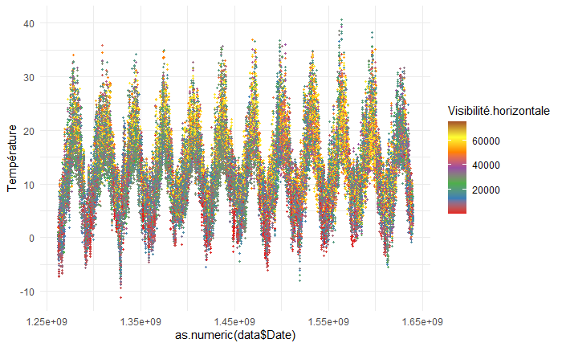

```r
TemperatureAnnee <-ggplot(data) +
        aes(
          x = as.numeric(data$Date),
          y = Température,
          colour = Visibilité.horizontale
        ) +
        geom_point(shape = "circle", size = 0.65) +
        scale_color_distiller(palette = "Set1", direction = 1) +
        theme_minimal()
TemperatureAnnee
```

On remarque une forte saisonnalité.

Pour analyser uniquement la tendance, nous allons devoir annuler les saisonnalités, nous utiliserons pour ce faire les moyennes mobiles.

Moyenne mobile 2x2920

```r
library(forecast)
MM_ordre_2x150 <- ma(data$Température, 2920)
```

Affichage de la moyenne mobile

```r
ggsave(plotMeteo, ,  filename = '2Meteo.png', dpi = 1500, type = 'cairo',
       width = 8, height = 5, units = 'in')
```

[output not shown]

Test de Coax Stuart pour savoir si la tendance est significative.

```r
library(randtests)
cox.stuart.test(na.omit(MM_ordre_2x150), 'left.sided')
```

```
    Cox Stuart test

data:  na.omit(MM_ordre_2x150)
statistic = 12296, n = 15967, p-value = 1
alternative hypothesis: decreasing trend
```

Nous devons donc utilisé des modèles prédictifs prenant en compte la tendance et la saisonnalité pour nos prédictions. Nous pouvons pour ce faire utilisé le modèle de Buys Ballot, de plus nous pouvons utilisé des modèles à plusieurs inputs tel SARIMA & LSTM pour tirer partie des collonnes autres que Date et Température.

## Préparation des données pour les modèles

|  | Date | Pression.au.niveau.mer | Variation.de.pression.en.3.heures | Direction.du.vent.moyen.10.mn | Vitesse.du.vent.moyen.10.mn | Température | Point.de.rosée | Humidité | Visibilité.horizontale | Pression.station | Rafales.sur.une.période | Précipitations.dans.la.dernière.heure | Précipitations.dans.les.3.dernières.heures | Annee | Mois | Jour | Heure | DateNumerique | moisCycle | JourCycle | HeureCycle |
| --- | --- | --- | --- | --- | --- | --- | --- | --- | --- | --- | --- | --- | --- | --- | --- | --- | --- | --- | --- | --- | --- |
| 7729 |  | 100960 | 360 | 260 | 1.5 | -0.05 | 270.05 | 79 | 15000 | 99570 | 2.1 | 0.0 | 0.0 | 2010 | 01 | 01 | 19 | 1262368800 | 0.00000000 | 0.00000000 | 0.75000000 |
| 9767 |  | 99320 | 0 | 30 | 4.6 | 3.55 | 275.55 | 93 | 4000 | 97970 | 10.3 | 0.0 | 0.0 | 2010 | 01 | 01 | 01 | 1262304000 | 0.00000000 | 0.00000000 | 0.00000000 |
| 10343 |  | 101240 | 270 | 270 | 1.5 | -1.45 | 269.85 | 87 | 15000 | 99840 | 1.5 | 0.0 | 0.0 | 2010 | 01 | 01 | 22 | 1262379600 | 0.00000000 | 0.00000000 | 0.87500000 |
| 12561 |  | 99400 | 70 | 20 | 4.6 | 1.95 | 273.95 | 93 | 2600 | 98040 | 9.3 | 0.0 | 0.0 | 2010 | 01 | 01 | 04 | 1262314800 | 0.00000000 | 0.00000000 | 0.12500000 |
| 14539 |  | 99610 | 210 | 360 | 5.1 | 1.05 | 272.55 | 90 | 7000 | 98250 | 10.3 | 0.0 | 0.0 | 2010 | 01 | 01 | 07 | 1262325600 | 0.00000000 | 0.00000000 | 0.25000000 |
| 14540 |  | 100250 | 300 | 330 | 5.7 | 0.65 | 270.95 | 82 | 10000 | 98880 | 8.2 | 0.0 | 0.0 | 2010 | 01 | 01 | 13 | 1262347200 | 0.00000000 | 0.00000000 | 0.50000000 |
| 21640 |  | 100580 | 330 | 350 | 3.6 | 1.85 | 270.35 | 72 | 17000 | 99210 | 8.7 | 0.0 | 0.0 | 2010 | 01 | 01 | 16 | 1262358000 | 0.00000000 | 0.00000000 | 0.62500000 |
| 23009 |  | 99950 | 330 | 360 | 4.6 | 0.65 | 271.75 | 87 | 6000 | 98580 | 8.7 | 0.0 | 0.0 | 2010 | 01 | 01 | 10 | 1262336400 | 0.00000000 | 0.00000000 | 0.37500000 |
| 339 |  | 101630 | 160 | 250 | 1.0 | -3.05 | 269.15 | 93 | 15000 | 100220 | 1.5 | 0.0 | 0.0 | 2010 | 01 | 02 | 04 | 1262401200 | 0.00000000 | 0.03225806 | 0.12500000 |
| 2815 |  | 101680 | 0 | 210 | 1.5 | 0.45 | 270.85 | 83 | 15000 | 100830 | 2.1 | 0.0 | 0.0 | 2010 | 01 | 02 | 19 | 1262455200 | 0.00000000 | 0.03225806 | 0.75000000 |

[output cut: 990 more lines]

Nous entraînerons nos modèles sur 80% des premières observations et réaliserons les prédictions sur les 20% suivantes. Nous pourrons ainsi avoir une belle représentation graphique des prédictions comparés aux données réelles.

```r
#Nombre de lignes totales
n = nrow(data)

#80% données
data_Train <- data[1:(n *0.8),]
#20% données
data_Test <- data[((n*0.8)):n,]
```

On remarque que les données du jeu de Test, commence le premier aout 2019.

Fonction Affichage donnée prédite

```r
Affichage_Prediction <- function(Donnees, Modele){
  library(ggplot2)
  library(ggthemes)

  p <- ggplot(data =Donnees, aes(x = DateNumerique, colour = Visibilité.horizontale) ) +
    scale_color_distiller(palette = "Set1", direction = 1) +

    geom_point(aes(y = Température),shape = "circle", size = 0.65) +
       geom_point(aes(y = Modele), size = 1.2, color = "blue")+
  #  geom_line(aes(y = Modele), size = 1.2, alpha = 0.6, color = "blue")+


    labs(x="Années",
         y= "Température")+
    theme_fivethirtyeight()+
    theme(axis.title = element_text(), text = element_text(family = "Rubik"))

 #Prédiction sur l'année 2019
  p2 <- ggplot(data =Donnees, aes(x = DateNumerique, y = Température) ) +
    geom_point(aes(y = Température),shape = "circle", size = 0.1)+
    geom_line(aes(y = Modele), size = 0.9, alpha = 0.9, color = "blue")+
    theme_fivethirtyeight()+
    xlim (1564660800, 1639958400) +
    ylim (-10, 35)


  #Ajout zoom sur 2019
 return( p +
    annotation_custom(ggplotGrob(p2), xmin = 1262368800, xmax = 1592724800, ymin = -35, ymax = 0) +
    geom_rect(aes(xmin = 1262368800, xmax = 1592724800, ymin = -35, ymax =  0), color='black', linetype='dashed', alpha=0) )

return(p)
}
```

# Buys Ballot Modèle

## Estimation de la tendance

```r
#création d'une droite de régression
Tendance <- lm(Température~DateNumerique,data = data_Train)

# Prédiction de la tendance sur le jeu d'entrainement
tendance=predict(Tendance)

#Prédiction de la tendance sur le jeu de Test
tendance2=predict(Tendance, newdata=data_Test)

TendancePredite <- c(tendance, tendance2)
```

Affichage de la tendance

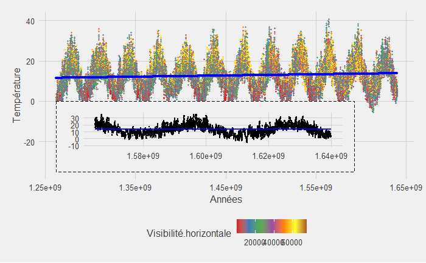

```r
plotMeteo
```

Estimation saisonnalité annuelle

```r
data_Train$ResidusTendance <- residuals(Tendance)

EstimationSaisoAnnuelle =lm(ResidusTendance~0+as.factor(moisCycle),data=data_Train)
```

Prédictions de la saisonnalité annuelle

```r
#Jeu d'entrainement
SaisoAnnuelTrain <- predict(EstimationSaisoAnnuelle)

#Jeu de test
SaisoAnnuelTest <- predict(EstimationSaisoAnnuelle, newdata=data_Test)

SaisonnaliteAnnuellePredite <- c(SaisoAnnuelTrain,SaisoAnnuelTest)
```

Affichage avec la saisonnalité annuelle ajoutée

```r
plotMeteo <- Affichage_Prediction(data, TendancePredite+SaisonnaliteAnnuellePredite)
ggsave(plotMeteo, ,  filename = '3Meteo.png', dpi = 1500, type = 'cairo',
       width = 8, height = 5, units = 'in')
```

Estimation saisonnalité mensuelle

```r
data_Train$ResidusSaisoAnnuelle <- residuals(EstimationSaisoAnnuelle)

EstimationSaisoMensuelle =lm(ResidusSaisoAnnuelle~0+as.factor(JourCycle),data=data_Train)
```

Prédiction avec la saisonnalité mensuelle rajoutée

```r
#Jeu d'entrainement
SaisoMensuelleTrain <- predict(EstimationSaisoMensuelle)

#Jeu de test
SaisoMensuelleTest <- predict(EstimationSaisoMensuelle, newdata=data_Test)

SaisonnaliteMensuellePredite <- c(SaisoMensuelleTrain,SaisoMensuelleTest)
```

Affichage

```r
plotMeteo <-  Affichage_Prediction(data, TendancePredite+SaisonnaliteAnnuellePredite+SaisonnaliteMensuellePredite)
ggsave(plotMeteo, ,  filename = '4Meteo.png', dpi = 1500, type = 'cairo',
       width = 8, height = 5, units = 'in')
```

On re-itère cela avec la saisonnalité journalière

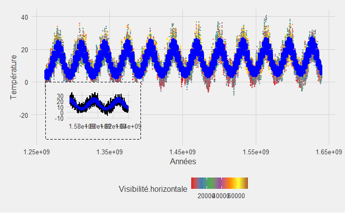

```r
data_Train$ResidusSaisoMensuelle <- residuals(EstimationSaisoMensuelle)
EstimationSaisoJournaliere =lm(ResidusSaisoMensuelle~0+as.factor(HeureCycle),data=data_Train)
SaisoJournaliereTrain <- predict(EstimationSaisoJournaliere)
SaisoJournaliereTest <- predict(EstimationSaisoJournaliere, newdata=data_Test)
SaisonnaliteJournalierePredite <- c(SaisoJournaliereTrain,SaisoJournaliereTest)
Affichage_Prediction(data, TendancePredite+SaisonnaliteAnnuellePredite+SaisonnaliteMensuellePredite+SaisonnaliteJournalierePredite)
```

## Affichage Prédictions

```r
plotMeteo <-  Affichage_Prediction(data, TendancePredite+SaisonnaliteAnnuellePredite+SaisonnaliteMensuellePredite+SaisonnaliteJournalierePredite)
ggsave(plotMeteo, ,  filename = '5Meteo.png', dpi = 1500, type = 'cairo',
       width = 8, height = 5, units = 'in')
```

# LSTM modèle

Source & traduit depuis http://datasideoflife.com/?p=1171

## Préparation des données

Le modèle LSTM nécessite des données normalisés

```r
scale_factors <- c(mean(data_Train$Température), sd(data_Train$Température))
scaled_train <- data_Train %>%
    dplyr::select(Température) %>%
    dplyr::mutate(Température = (Température - scale_factors[1]) / scale_factors[2])
```

On souhaite prédire les 6971 prochaine valeurs.

L’algorithme LSTM crée des prédictions basées sur les valeurs décalées. Cela signifie qu’il doit se référer à autant de valeurs précédentes que de points que nous souhaitons prédire. Comme nous voulons faire une prévision sur 6971 obs, nous devons baser chaque prédiction sur 6971 points de données.

```r
prediction <- 6971
lag <- prediction
```

De plus, keras LSTM attend un format tensoriel spécifique de la forme d’un tableau 3D de la forme [samples, timesteps, features] pour les prédicteurs (X) et pour les valeurs cibles (Y) :

- samples spécifie le nombre d’observations qui seront traitées par lots.
- timesteps nous indique le nombre de “pas” de temps (lags). Ou en d’autres termes, combien d’unités de temps en arrière nous voulons que notre réseau voit.
- features spécifie le nombre de prédicteurs (1 pour les séries univariées et n pour les séries multivariées).

Dans le cas des prédicteurs, cela se traduit par un tableau de dimensions : (nrow(data) - lag - prediction + 1, 6971, 1), où lag = prediction = 6971.

```r
scaled_train <- as.matrix(scaled_train)

# we lag the data 6970 times and arrange that into columns
x_train_data <- t(sapply(
    1:(length(scaled_train) - lag - prediction + 1),
    function(x) scaled_train[x:(x + lag - 1), 1]
  ))

# now we transform it into 3D form
x_train_arr <- array(
    data = as.numeric(unlist(x_train_data)),
    dim = c(
        nrow(x_train_data),
        lag,
        1
    )
)
#length(x_train_arr)
```

```r
y_train_data <- t(sapply(
    (1 + lag):(length(scaled_train) - prediction + 1),
    function(x) scaled_train[x:(x + prediction - 1)]
))

y_train_arr <- array(
    data = as.numeric(unlist(y_train_data)),
    dim = c(
        nrow(y_train_data),
        prediction,
        1
    )
)
#length(y_train_data)
```

On prépare les données pour la prédiction, il s’agit de nos 6971 dernières observations.

```r
x_test <- data$y[(nrow(scaled_train) - prediction + 1):nrow(scaled_train)]

x_test_scaled <- (x_test - scale_factors[1]) / scale_factors[2]

x_pred_arr <- array(
    data = x_test_scaled,
    dim = c(
        1,
        lag,
        1
    )
)
```

## Création du modèle

```r
lstm_model <- keras_model_sequential()

lstm_model %>%
  layer_lstm(units = 3, #50 size of the layer
       batch_input_shape = c(1, dim(x_train_arr)[2], dim(x_train_arr)[3]), # batch size, timesteps, features
       return_sequences = TRUE,
       stateful = TRUE) %>%
  # fraction of the units to drop for the linear transformation of the inputs
  layer_dropout(rate = 0.5) %>%
  layer_lstm(units = 3, #50
        return_sequences = TRUE,
        stateful = TRUE) %>%
  layer_dropout(rate = 0.5) %>%
  time_distributed(keras::layer_dense(units = 1))

lstm_model %>%
    compile(loss = 'mae', optimizer = 'adam', metrics = 'accuracy')

summary(lstm_model)
```

```
Model: "sequential_5"
____________________________________________________________________________________________________________________________________________________
 Layer (type)                                                     Output Shape                                               Param #
====================================================================================================================================================
 lstm_11 (LSTM)                                                   (1, 6971, 3)                                               60
 dropout_11 (Dropout)                                             (1, 6971, 3)                                               0
 lstm_10 (LSTM)                                                   (1, 6971, 3)                                               84
 dropout_10 (Dropout)                                             (1, 6971, 3)                                               0
 time_distributed_5 (TimeDistributed)                             (1, 6971, 1)                                               4
====================================================================================================================================================
Total params: 148
Trainable params: 148
Non-trainable params: 0
____________________________________________________________________________________________________________________________________________________
```

Entrainement du modèle avec Shuffle en False pour garder la logique des données chronologiques

```r
lstm_model %>% fit(
    x = x_train_arr,
    y = y_train_arr,
    batch_size = 1,
    epochs = 20,
    verbose = 0,
    shuffle = FALSE
)
```

## Prediction sur jeu d’entrainement

```r
# lstm_forecast <- lstm_model %>%
#     predict(x_pred_arr, batch_size = 1) %>%
#     .[, , 1]
#
# # rescale en format basique
# lstm_forecast <- lstm_forecast * scale_factors[2] + scale_factors[1]
# lstm_forecast
```

X résultats prédictions par input donc transforme pour une seule prédiction

```r
# fitted <- predict(lstm_model, x_train_arr, batch_size = 1) %>%
#      .[, , 1]
#
# if (dim(fitted)[2] > 1) {
#
#     fit <- c(fitted[, 1], fitted[dim(fitted)[1], 2:dim(fitted)[2]])
# } else {
#     fit <- fitted[, 1]
# }
#
# # rescale final de nos données
# fitted <- fit * scale_factors[2] + scale_factors[1]
# fitted <- c(rep(NA, lag), fitted)
# length(fitted)
```

```r
# lstm_forecast <- ts(lstm_forecast,
#     start = c(2019, 1),
#     end = c(2019, 12),
#     frequency = 12
# )
#
# lstm_forecast_display <- window(lstm_forecast, start= c(2019,1), end = c(2019,8))
#
# input_ts <- ts(data$y,
#     start = c(2011, 1),
#     end = c(2018, 12),
#     frequency = 12)
#
#
# lstm_forecast_display
# data_ts_test
#
# plot(input_ts, xlim=c(2011,2020))
# #lines(data_ts_test)
# lines(lstm_forecast_display, col=3)
```

# Indicateurs de Performance sur les modèles

## Choix indicateurs

Nous utiliesrons les indicateurs R² et MAPE

```r
#L'erreur absolue moyenne en pourcentage
MAPE <-  function(donnees_reelle,donnees_predites){
  return (mean(abs((donnees_reelle - donnees_predites)/donnees_reelle))*100)
}

#R²
Rcarre <- function(donnees_reelle,donnees_predites){

  # le carré de leur corrélation
  #cor(donnees_reelle,donnees_predites)^2


  SCR <- sum((donnees_predites - donnees_reelle)^2)

  SCT <- sum((donnees_reelle - mean(donnees_reelle))^2)

  #on calcule le R² classique
  Rcarre <- 1 - (SCR / SCT)

  return(Rcarre)

  #                 (SCR)/n-p-1
  #R² ajusté = 1 -  ____________
  #                 (SCT)/n-p
  # SCT = SCR + SCE => SCR = SCT - SCT
  #RcarreAjust = 1 - ((SCR)/(nrow(prevision) -22 )/ (SCT/(nrow(prevision)-21)))
}
```

Sur le modèle de Buys-Ballot

```r
EnsemblePreditBuysBallot <- TendancePredite+SaisonnaliteAnnuellePredite+SaisonnaliteMensuellePredite+SaisonnaliteJournalierePredite
TrainPreditBuysBallot <- tendance + SaisoAnnuelTrain + SaisoMensuelleTrain + SaisoJournaliereTrain
TestPreditBuysBallot <- tendance2 + SaisoAnnuelTest + SaisoMensuelleTest + SaisoJournaliereTest

#Dans l'ensemble des données
cat("Rcarré globale : ",Rcarre(data$Température, EnsemblePreditBuysBallot),"\n")
```

```
Rcarré globale :  0.656205
```

```r
cat("Rcarré Entrainement : ",Rcarre(data_Train$Température, TrainPreditBuysBallot),"\n")
```

```
Rcarré Entrainement :  0.7242252
```

```r
cat("Rcarré Test : ",Rcarre(data_Test$Température, TestPreditBuysBallot),"\n")
```

```
Rcarré Test :  0.6840867
```

## MAPE

sur le modèle de Buys-Ballot

```r
cat("MAPE globale : ",MAPE(data$Température, EnsemblePreditBuysBallot),"\n")
```

```
MAPE globale :  101.8649
```

```r
cat("MAPE Entrainement : ",MAPE(data_Train$Température, TrainPreditBuysBallot),"\n")
```

```
MAPE Entrainement :  101.5681
```

```r
cat("MAPE Test : ",MAPE(data_Test$Température, TestPreditBuysBallot),"\n")
```

```
MAPE Test :  84.60385
```